# urlset_scraper_post_processing

Zorbey Özcan

2025-05-26

# Overview: Post-Processing and Retry Framework for Sitemap URLSet Extraction

This document presents a comprehensive post-processing pipeline designed to enhance the completeness and reliability of news article URL extraction from sitemap data. Building upon the primary urlset_scraper framework, this system implements a systematic retry mechanism, result consolidation, and analytical reporting suite to maximize data coverage and ensure methodological transparency.

The pipeline operates on the serialized outputs of the initial scraping process, reconstructing the processing environment and applying targeted retry logic to previously failed requests. Through VPN rotation and user-agent diversification, the system attempts to overcome temporary network barriers, rate limiting, and access restrictions that may have affected the initial extraction phase. The framework distinguishes between persistent technical failures and transient connectivity issues, providing granular classification of error types and resolution outcomes.

Core functionalities include the reconstruction of global processing state from archived data tables, implementation of retry-specific progression tracking, execution of the master processing loop on failed entries, comparative analysis of pre- and post-retry error patterns, and generation of comprehensive summary statistics and visualizations. The system maintains full methodological traceability through detailed logging and produces both domain-level and sitemap-level analytical reports suitable for academic replication and validation. Inputs include serialized progression tables, output data, error logs, and master tracking structures from the initial scraping phase, along with VPN configuration and user-agent rotation parameters. Outputs comprise enhanced URLSet collections with increased coverage, comparative error analysis, temporal trend visualizations, and structured summary tables documenting the effectiveness of the retry methodology across different news domains and temporal periods.

## Code Chunk 1: Initial Setup and Library Loading

This code chunk initializes the R Markdown environment for the post-processing pipeline by configuring knitting options and loading all required analytical libraries. It sets global options to suppress messages and warnings during knitting, ensuring cleaner output for academic documentation. The chunk loads a comprehensive set of packages for data manipulation (tidyverse, data.table), HTTP requests (httr), XML parsing (xml2), logging (futile.logger), temporal analysis (lubridate), and advanced visualization (ggplot2, viridis, cowplot).

Additionally, it defines three critical directory paths: the main output folder for final results, the working data folder containing intermediate processing outputs from the primary scraper, and the documentation folder for logs and analytical reports. These folder definitions establish the organizational structure for the entire post-processing workflow, ensuring consistent file management and facilitating reproducible research practices. The setup ensures that all subsequent chunks operate within a correctly initialized environment with access to necessary analytical tools and standardized file paths.

```r
# Set knitting options for clean output
knitr::opts_chunk$set(
  echo    = TRUE,    # show code
  message = FALSE,   # suppress messages
  warning = FALSE    # suppress warnings
)

# Load core libraries for data processing, HTTP requests, XML parsing and logging
library(tidyverse)
library(data.table)
library(xml2)
```

```r
library(httr)
library(stringr)
library(purrr)
library(futile.logger)
library(lubridate)
library(ggplot2)
library(viridis)
library(grid)
library(cowplot)
step_1_output_folder <- "/Users/zorbeyozcan/newsmedia_scraper/data"
step_1_working_data_output_folder <- "/Users/zorbeyozcan/newsmedia_scraper/working_data/urlset_scraper_output"
step_1_logging_folder <- "/Users/zorbeyozcan/newsmedia_scraper/documentation"


cat("Step 1 completed: Packages loaded, outputfolder defined.\n")
```

```
## Step 1 completed: Packages loaded, outputfolder defined.
```

## Code Chunk 2: Loading Input Data and Importing Functions from Primary Scraper

### Summary:

This code chunk performs dual initialization by loading serialized data outputs from the primary scraping process and importing all necessary functions and variables from the original urlset_scraper framework. The chunk ensures complete operational independence for the post-processing pipeline while maintaining full compatibility with the primary scraper’s methodology and data structures.

````r
# Define folder containing .rds files for retry processing
step_2_input_folder <- "/Users/zorbeyozcan/newsmedia_scraper/working_data/urlset_scraper_output"

# Enumerate all .rds files in the input folder
step_2_input_files <- list.files(
  path      = step_2_input_folder,
  pattern   = "\\.rds$",
  full.names = TRUE
)

# Build a table of file paths and corresponding object names
step_2_input_files_df <- data.table(
  file_path   = step_2_input_files,
  object_name = basename(step_2_input_files) %>% str_remove("\\.rds$")
)

# Load each .rds file into the global environment under its original object name
for (i in seq_len(nrow(step_2_input_files_df))) {
  fp  <- step_2_input_files_df$file_path[i]
  nm  <- step_2_input_files_df$object_name[i]
  obj <- readRDS(fp)
  assign(nm, obj, envir = .GlobalEnv)
}

# Loading all essential function from "urlset_scraper" for post-processing
rmd_file_path <- file.path("/Users/zorbeyozcan/newsmedia_scraper/code/urlset_scraper.Rmd")

if (!file.exists(rmd_file_path)) {
  stop("urlset_scraper.Rmd not found in current directory. Please ensure both files are in the same folder.")
}

# Read the RMD file content
rmd_content <- readLines(rmd_file_path)

# Extract and execute chunk 3 (Global Parameters)
chunk3_start <- which(grepl("Step 3: Set Global Parameters", rmd_content))
chunk3_end <- which(grepl("Step 3 completed", rmd_content))
if (length(chunk3_start) > 0 && length(chunk3_end) > 0) {
  chunk3_code <- rmd_content[(chunk3_start[1]+1):(chunk3_end[1]-1)]
  chunk3_code <- chunk3_code[!grepl("^```", chunk3_code)]
  eval(parse(text = paste(chunk3_code, collapse = "\n")))
}

# Extract and execute chunk 5 (Date-check helper functions)
chunk5_start <- which(grepl("Step 5: Defining date-check helper functions", rmd_content))
chunk5_end <- which(grepl("Step 5 completed", rmd_content))
if (length(chunk5_start) > 0 && length(chunk5_end) > 0) {
  chunk5_code <- rmd_content[(chunk5_start[1]+1):(chunk5_end[1]-1)]
  chunk5_code <- chunk5_code[!grepl("^```", chunk5_code)]
  eval(parse(text = paste(chunk5_code, collapse = "\n")))
}

# Extract and execute chunk 6 (Sorting functions)
chunk6_start <- which(grepl("Step 6: Defining sorting functions", rmd_content))
chunk6_end <- which(grepl("Step 6 completed", rmd_content))
if (length(chunk6_start) > 0 && length(chunk6_end) > 0) {
  chunk6_code <- rmd_content[(chunk6_start[1]+1):(chunk6_end[1]-1)]
  chunk6_code <- chunk6_code[!grepl("^```", chunk6_code)]
  eval(parse(text = paste(chunk6_code, collapse = "\n")))
}

# Extract and execute chunk 7 (Core functions for processing sitemaps)
chunk7_start <- which(grepl("Step 7: Defining core functions for processing sitemaps", rmd_content))
chunk7_end <- which(grepl("Step 7 completed", rmd_content))
if (length(chunk7_start) > 0 && length(chunk7_end) > 0) {
  chunk7_code <- rmd_content[(chunk7_start[1]+1):(chunk7_end[1]-1)]
  chunk7_code <- chunk7_code[!grepl("^```", chunk7_code)]
  eval(parse(text = paste(chunk7_code, collapse = "\n")))
}

# Extract and execute chunk 8 (Main recursive sitemap processing function)
chunk8_start <- which(grepl("Step 8: Main recursive sitemap processing function", rmd_content))
chunk8_end <- which(grepl("Step 8 completed", rmd_content))
if (length(chunk8_start) > 0 && length(chunk8_end) > 0) {
  chunk8_code <- rmd_content[(chunk8_start[1]+1):(chunk8_end[1]-1)]
  chunk8_code <- chunk8_code[!grepl("^```", chunk8_code)]
  eval(parse(text = paste(chunk8_code, collapse = "\n")))
}

# Extract and execute chunk 9 (Master Loop)
chunk9_start <- which(grepl("Step 9: Defining the Master Loop", rmd_content))
chunk9_end <- which(grepl("Step 9 completed", rmd_content))
if (length(chunk9_start) > 0 && length(chunk9_end) > 0) {
  chunk9_code <- rmd_content[(chunk9_start[1]+1):(chunk9_end[1]-1)]
  chunk9_code <- chunk9_code[!grepl("^```", chunk9_code)]
  eval(parse(text = paste(chunk9_code, collapse = "\n")))
}

# Verify that essential functions and variables are loaded
essential_objects <- c(
  "global_date_start", "global_date_end", "global_excluded_strings",
  "global_user_agent_list", "step_5_1_date_check_urlset_func",
  "step_5_2_date_check_link_func", "step_6_sorting_func",
  "step_7_1_progression_update", "step_7_2_master_dt_update_func",
  "step_7_3_response_log_update_func", "step_7_4_urlset_scraper_func",
  "step_8_recursive_processing_func", "step_9_master_loop_func"
)

missing_objects <- essential_objects[!sapply(essential_objects, exists)]
if (length(missing_objects) > 0) {
  warning(paste("Missing essential objects:", paste(missing_objects, collapse = ", ")))
} else {
  cat("All essential functions and variables loaded successfully.\n")
}
````

```
## All essential functions and variables loaded successfully.
```

```r
cat("Step 2 completed: Inputs loaded and functions imported from part 1.\n")
```

```
## Step 2 completed: Inputs loaded and functions imported from part 1.
```

## VPN Configuration and User-Agent Rotation Setup for Retry Operations

### Summary:

This code chunk establishes a differentiated network configuration for retry operations by implementing VPN verification protocols and defining alternative user-agent strings to maximize the probability of successful request completion during the retry phase. The chunk ensures operational security and methodological rigor by preventing accidental execution under identical network conditions as the initial scraping session.

```r
# Retrieve the current external IP address for retry operations
global_vpn_ip_retry <- trimws(suppressWarnings(readLines("https://ifconfig.me/ip")))

# Compare the retry IP with the original IP and issue a warning if they match
if (exists("global_vpn_ip") && identical(global_vpn_ip_retry, global_vpn_ip)) {
  warning("Change VPN before proceeding.")
}

# Define new user-agent strings for retry request rotation
step_3_user_agent_1 <- "Mozilla/5.0 (X11; Linux x86_64) AppleWebKit/537.36 (KHTML, like Gecko) Chrome/125.0.6378.0 Safari/537.36"

step_3_user_agent_2 <- "Mozilla/5.0 (Windows NT 10.0; Win64; x64; rv:120.0) Gecko/20100101 Firefox/120.0"

step_3_user_agent_3 <- "Mozilla/5.0 (iPhone; CPU iPhone OS 17_5 like Mac OS X) AppleWebKit/605.1.15 (KHTML, like Gecko) Version/17.5 Mobile/15E148 Safari/604.1"

step_3_user_agent_4 <- "Mozilla/5.0 (Macintosh; Intel Mac OS X 14_0) AppleWebKit/537.36 (KHTML, like Gecko) Chrome/125.0.0.0 Safari/537.36"

step_3_user_agent_5 <- "Mozilla/5.0 (X11; Ubuntu; Linux x86_64; rv:122.0) Gecko/20100101 Firefox/122.0"

# Assemble the retry-specific user-agent rotation list
global_user_agent_list_retry <- c(
  step_3_user_agent_1,
  step_3_user_agent_2,
  step_3_user_agent_3,
  step_3_user_agent_4,
  step_3_user_agent_5
)


cat("Step 3 completed: VPN set and compared, new user agents defined.\n")
```

```
## Step 3 completed: VPN set and compared, new user agents defined.
```

## Code Chunk 4: Creating Empty Retry Response Log Tables

### Summary:

This code chunk initializes dedicated response logging infrastructure for the retry phase by creating empty retry-specific log tables that mirror the schema of original response logs while maintaining clear separation between initial and retry processing phases. The chunk ensures systematic tracking of retry attempt outcomes and enables comparative analysis of error patterns across processing phases.

#### Retry Log Table Initialization:

Iterates through each entry in the global_retry_master_dt table to identify sitemaps requiring retry processing. For each identified sitemap, constructs standardized naming conventions for both original and retry response log tables using the pattern sitemap_id_*response_log_dt and sitemap_id*_retry_response_log_dt respectively.

```r
# For each entry in the retry master table, create an empty retry response log
if (exists("global_retry_master_dt", envir = .GlobalEnv)) {
  for (i in seq_len(nrow(global_retry_master_dt))) {
    # Identify the sitemap layer ID
    step_5_layer_id <- global_retry_master_dt$layer_1_url_id[i]

    # Construct original and retry log table names
    step_5_orig_log_name  <- paste0("sitemap_id_", step_5_layer_id, "_response_log_dt")
    step_5_retry_log_name <- paste0("sitemap_id_", step_5_layer_id, "_retry_response_log_dt")

    # If the original response log exists, derive its schema
    if (exists(step_5_orig_log_name, envir = .GlobalEnv)) {
      step_5_orig_log_df  <- get(step_5_orig_log_name, envir = .GlobalEnv)
      # Initialize zero-row copy for retry logs
      step_5_retry_log_df <- step_5_orig_log_df[0]
      # Assign the empty retry log table
      assign(step_5_retry_log_name, step_5_retry_log_df, envir = .GlobalEnv)
    }
  }
}


cat("Step 4 completed: Empty retry response log created.\n")
```

```
## Step 4 completed: Empty retry response log created.
```

## Code Chunk 5: Executing Master Loop on Retry Infrastructure with Environment Substitution

### Summary:

#### Master Loop Excecution:

Invokes the step_9_master_loop_func() function within the modified environment, enabling it to process retry entries using identical logic and error handling mechanisms as the original scraping phase. The loop applies the same recursive processing, status tracking, and error classification procedures to retry entries, but operates under different network conditions (VPN rotation) and user-agent profiles.

```r
# Backup and replace original master and user-agent list
step_5_master_backup       <- global_master_dt
step_5_user_agents_backup  <- global_user_agent_list

# Replace master table and UA list for retry processing
global_master_dt         <- global_retry_master_dt
global_user_agent_list   <- global_user_agent_list_retry

# Backup Replace progression tables with retry versions
for (i in seq_len(nrow(global_retry_master_dt))) {
  lid <- global_retry_master_dt$layer_1_url_id[i]

  # Backup original progression table
  orig_prog_name <- paste0("sitemap_id_", lid, "_progression_dt")
  retry_prog_name <- paste0("sitemap_id_", lid, "_retry_progression_dt")

  if (exists(retry_prog_name, envir = .GlobalEnv)) {
    # Backup original
    assign(paste0(orig_prog_name, "_backup"),
           get(orig_prog_name, envir = .GlobalEnv),
           envir = .GlobalEnv)

    # Replace with retry version
    assign(orig_prog_name,
           get(retry_prog_name, envir = .GlobalEnv),
           envir = .GlobalEnv)
  }
}


# Invoke the master loop on the retry master table
step_9_master_loop_func()

# Restore original master table and user-agent list
global_master_dt         <- step_5_master_backup
global_user_agent_list   <- step_5_user_agents_backup
```

## Code Chunk 6: Extracting Links from URLSet Output Tables and Applying Temporal Filtering

### Summary:

This code chunk performs comprehensive URL extraction from all scraped URLSet XML content, implements sophisticated date parsing and prioritization logic, and applies temporal filtering to create clean datasets for downstream analysis. The chunk serves as the primary data consolidation phase, transforming raw XML sitemap content into structured tabular data suitable for sociotechnical analysis and visualization.

#### Output:

The generated output “step_6_results_dt_filtered” is the data set that will be the basis of the link_scraper, containing all valid links to scrape.

```r
# Initialize an empty table for all extracted links and dates
step_6_results_dt_all_links <- data.table(
  domain_id      = integer(),
  domain_url     = character(),
  layer_1_url_id = integer(),
  layer_1_url    = character(),
  urlset_url     = character(),
  result_link    = character(),
  lastmod_date   = as.Date(character()),
  pub_date       = as.Date(character()),
  date           = as.Date(character())
)

# Identify all output data tables in the environment
step_6_output_names <- ls(envir = .GlobalEnv, pattern = "^sitemap_id_[0-9]+_output_dt$")

for (nm in step_6_output_names) {
  step_6_out_dt <- get(nm, envir = .GlobalEnv)

  for (i in seq_len(nrow(step_6_out_dt))) {
    raw <- step_6_out_dt$urlset_content[i]
    if (is.na(raw) || !nzchar(raw)) next
    doc <- tryCatch(read_xml(raw), error = function(e) NULL)
    if (is.null(doc)) next

    ns_defs <- c(
      ns   = "http://www.sitemaps.org/schemas/sitemap/0.9",
      news = "http://www.google.com/schemas/sitemap-news/0.9"
    )

    loc_nodes     <- xml_find_all(doc,       ".//ns:loc",                ns = ns_defs)
    lastmod_nodes <- xml_find_all(doc,       ".//ns:lastmod",            ns = ns_defs)
    pub_nodes     <- xml_find_all(doc,       ".//news:publication_date", ns = ns_defs)

    links    <- xml_text(loc_nodes)
    mods_raw <- xml_text(lastmod_nodes)
    pubs_raw <- xml_text(pub_nodes)

    mods_clean <- gsub("T.*", "", mods_raw)
    mods_clean[!str_detect(mods_clean, "^\\d{4}-\\d{2}-\\d{2}$")] <- NA
    mods_final <- as.Date(mods_clean)

    pubs_clean <- gsub("T.*", "", pubs_raw)
    pubs_clean[!str_detect(pubs_clean, "^\\d{4}-\\d{2}-\\d{2}$")] <- NA
    pubs_final <- as.Date(pubs_clean)

    mods_final <- rep(mods_final, length.out = length(links))
    pubs_final <- rep(pubs_final, length.out = length(links))

    keep_idx <- which(str_detect(links, "^https?://"))
    if (!length(keep_idx)) next

    tmp <- data.table(
      domain_id      = step_6_out_dt$domain_id[i],
      domain_url     = step_6_out_dt$domain_url[i],
      layer_1_url_id = step_6_out_dt$layer_1_url_id[i],
      layer_1_url    = step_6_out_dt$layer_1_url[i],
      urlset_url     = step_6_out_dt$urlset_url[i],
      result_link    = links[keep_idx],
      lastmod_date   = mods_final[keep_idx],
      pub_date       = pubs_final[keep_idx]
    )

    # combined date column (pub_date prioritized)
    tmp[, date := coalesce(pub_date, lastmod_date)]

    step_6_results_dt_all_links <- rbind(step_6_results_dt_all_links, tmp, fill = TRUE)
  }
}

# Filter by combined date column
step_6_results_dt_filtered <- step_6_results_dt_all_links[
  is.na(date) | (date >= global_date_start & date <= global_date_end)
]

# Print summary statistics
cat(sprintf("Step 6 completed: Extracted links from output tables.\n"))
```

```
## Step 6 completed: Extracted links from output tables.
```

```r
cat(sprintf("Total links extracted: %d\n", nrow(step_6_results_dt_all_links)))
```

```
## Total links extracted: 1252309
```

```r
cat(sprintf("Links in date range or without dates: %d\n", nrow(step_6_results_dt_filtered)))
```

```
## Links in date range or without dates: 529035
```

```r
cat(sprintf("Links filtered out due to date: %d\n",
    nrow(step_6_results_dt_all_links) - nrow(step_6_results_dt_filtered)))
```

```
## Links filtered out due to date: 723274
```

## Code Chunk 7: Generating Comprehensive Result Overview Tables by Domain and Sitemap

### Summary:

This code chunk constructs detailed analytical summary tables that aggregate processing outcomes across domain and individual sitemap levels, providing comprehensive metrics for evaluating scraping effectiveness, error patterns, and retry success rates. The chunk implements sophisticated error categorization and retry comparison logic to enable systematic assessment of the pipeline’s performance and methodological robustness across different news sources and temporal periods.

#### Domain-Level Aggregation Process:

Creates a comprehensive domain overview table (step_7_result_overview_domain) that consolidates metrics across all sitemaps associated with each domain, including total link counts, valid link extraction rates, URLSet processing volumes, progression entry tracking, exclusion categorization, and error classification. This aggregation enables comparative analysis of scraping success across different news organizations and identification of domain-specific processing challenges.

#### Sitemap-Level Detailed Analysis:

Constructs granular sitemap-level summaries (step_7_result_overview_inputsitemap) that provide individual performance metrics for each input sitemap, enabling identification of specific problematic sitemaps and assessment of within-domain processing variability. This detailed tracking supports methodological transparency and facilitates targeted troubleshooting of persistent processing issues.

#### Multi-Source Metrics Integration Function:

Systematically queries multiple data sources for each sitemap including extracted link tables for content volume assessment, output tables for URLSet counting, progression tables for processing status evaluation, and error tables for exclusion and failure categorization. This integration provides comprehensive coverage of all processing outcomes and ensures no aspect of the pipeline’s performance remains untracked.

#### Error Categorization and Classification:

Distinguishes between multiple error types including string-based exclusions, date-based exclusions, XML parsing failures, HTTP response errors, and unsupported content types. Tracks both pre-retry and post-retry error counts to enable comprehensive evaluation of error resolution patterns and identification of persistent technical barriers.

#### Outputs:

```r
# Initialize result overview table by domain
step_7_result_overview_domain <- data.table(
  domain_id                      = integer(),
  domain_url                     = character(),
  total_links_for_domain         = integer(),
  total_valid_links              = integer(),
  total_urlsets                  = integer(),
  total_progression_entries      = integer(),
  total_links_excluded           = integer(),
  total_links_excluded_by_date   = integer(),
  total_links_excluded_by_string = integer(),
  total_errors                   = integer(),
  total_verified_errors_before_retry = integer(),
  total_verified_errors_after_retry  = integer(),
  total_unsolved_errors          = integer()
)

# Initialize result overview table by sitemap
step_7_result_overview_inputsitemap <- data.table(
  domain_id                      = integer(),
  domain_url                     = character(),
  layer_1_url_id                 = integer(),
  layer_1_url                    = character(),
  total_links_for_domain         = integer(),
  total_valid_links              = integer(),
  total_urlsets                  = integer(),
  total_progression_entries      = integer(),
  total_links_excluded           = integer(),
  total_links_excluded_by_date   = integer(),
  total_links_excluded_by_string = integer(),
  total_errors                   = integer(),
  total_verified_errors_before_retry = integer(),
  total_verified_errors_after_retry  = integer(),
  total_unsolved_errors          = integer()
)

# Get unique combinations of domain_id, domain_url, layer_1_url_id, and layer_1_url from master table
step_7_unique_entries <- unique(global_master_dt[, .(domain_id, domain_url, layer_1_url_id, layer_1_url)])

# Process each unique sitemap entry
for (i in seq_len(nrow(step_7_unique_entries))) {
  step_7_current_domain_id <- step_7_unique_entries$domain_id[i]
  step_7_current_domain_url <- step_7_unique_entries$domain_url[i]
  step_7_current_layer_id <- step_7_unique_entries$layer_1_url_id[i]
  step_7_current_layer_url <- step_7_unique_entries$layer_1_url[i]

  # Count total links for this sitemap from extracted links table
  step_7_total_links <- nrow(step_6_results_dt_all_links[layer_1_url_id == step_7_current_layer_id])

  # Count valid links (in range or no date)
  step_7_valid_links <- nrow(step_6_results_dt_filtered[layer_1_url_id == step_7_current_layer_id])

  # Count urlsets from output table
  step_7_output_name <- paste0("sitemap_id_", step_7_current_layer_id, "_output_dt")
  step_7_urlset_count <- if(exists(step_7_output_name, envir = .GlobalEnv)) {
    nrow(get(step_7_output_name, envir = .GlobalEnv))
  } else 0L

  # Count progression entries
  step_7_prog_name <- paste0("sitemap_id_", step_7_current_layer_id, "_progression_dt")
  step_7_prog_count <- if(exists(step_7_prog_name, envir = .GlobalEnv)) {
    nrow(get(step_7_prog_name, envir = .GlobalEnv))
  } else 0L

  # Count excluded by date from progression table
  step_7_excluded_date_prog <- if(exists(step_7_prog_name, envir = .GlobalEnv)) {
    nrow(get(step_7_prog_name, envir = .GlobalEnv)[processing_status == "excluded_by_date"])
  } else 0L

  # Count excluded entries from error table
  step_7_excluded_string_error <- nrow(global_error_dt[layer_1_url_id == step_7_current_layer_id &
                                                       error_category == "excluded_by_string"])
  step_7_excluded_input_error <- nrow(global_error_dt[layer_1_url_id == step_7_current_layer_id &
                                                      error_category == "input_out_of_range"])

  # Calculate total excluded counts
  step_7_total_excluded_by_date <- step_7_excluded_date_prog + step_7_excluded_input_error
  step_7_total_excluded_by_string <- step_7_excluded_string_error
  step_7_total_excluded <- step_7_total_excluded_by_date + step_7_total_excluded_by_string

  # Count errors
  step_7_parse_errors <- nrow(global_error_dt[layer_1_url_id == step_7_current_layer_id &
                                              error_category %in% c("xml_parse_error", "unsupported_root_tag")])
  step_7_response_errors <- if(exists(step_7_prog_name, envir = .GlobalEnv)) {
    nrow(get(step_7_prog_name, envir = .GlobalEnv)[processing_status == "response_error"])
  } else 0L
  step_7_total_errors <- step_7_parse_errors + step_7_response_errors

  # Process retry statistics
  step_7_orig_log_name <- paste0("sitemap_id_", step_7_current_layer_id, "_response_log_dt")
  step_7_retry_log_name <- paste0("sitemap_id_", step_7_current_layer_id, "_retry_response_log_dt")

  # Count errors before retry - check if retry_flag column exists
  step_7_errors_before_retry <- 0L
  if(exists(step_7_orig_log_name, envir = .GlobalEnv)) {
    step_7_orig_log_temp <- get(step_7_orig_log_name, envir = .GlobalEnv)
    if("retry_flag" %in% names(step_7_orig_log_temp)) {
      step_7_errors_before_retry <- nrow(step_7_orig_log_temp[retry_flag == TRUE])
    } else {
      # If retry_flag doesn't exist, count all entries as potential retries
      step_7_errors_before_retry <- nrow(step_7_orig_log_temp)
    }
  }

  # Calculate retry comparison metrics
  step_7_errors_after_retry <- 0L
  step_7_unsolved_errors <- 0L

  if(exists(step_7_orig_log_name, envir = .GlobalEnv) &&
     exists(step_7_retry_log_name, envir = .GlobalEnv)) {

    step_7_orig_log <- get(step_7_orig_log_name, envir = .GlobalEnv)
    step_7_retry_log <- get(step_7_retry_log_name, envir = .GlobalEnv)

    # Handle case where retry_flag might not exist
    if("retry_flag" %in% names(step_7_orig_log)) {
      step_7_orig_log_filtered <- step_7_orig_log[retry_flag == TRUE]
    } else {
      step_7_orig_log_filtered <- step_7_orig_log
    }

    if("retry_flag" %in% names(step_7_retry_log)) {
      step_7_retry_log_filtered <- step_7_retry_log[retry_flag == TRUE]
    } else {
      step_7_retry_log_filtered <- step_7_retry_log
    }

    # Join original and retry logs to find matching errors
    if(nrow(step_7_orig_log_filtered) > 0 && nrow(step_7_retry_log_filtered) > 0) {
      step_7_same_errors <- merge(
        step_7_orig_log_filtered[, .(requested_url, http_status_message)],
        step_7_retry_log_filtered[, .(requested_url, http_status_message)],
        by = c("requested_url", "http_status_message")
      )

      # Join to find different errors
      step_7_different_errors <- merge(
        step_7_orig_log_filtered[, .(requested_url, orig_status = http_status_message)],
        step_7_retry_log_filtered[, .(requested_url, retry_status = http_status_message)],
        by = "requested_url"
      )[orig_status != retry_status]

      step_7_errors_after_retry <- nrow(unique(step_7_same_errors, by = "requested_url"))
      step_7_unsolved_errors <- nrow(unique(step_7_different_errors, by = "requested_url"))
    }
  }

  # Add entry to sitemap overview table
  step_7_result_overview_inputsitemap <- rbind(
    step_7_result_overview_inputsitemap,
    data.table(
      domain_id                      = step_7_current_domain_id,
      domain_url                     = step_7_current_domain_url,
      layer_1_url_id                 = step_7_current_layer_id,
      layer_1_url                    = step_7_current_layer_url,
      total_links_for_domain         = step_7_total_links,
      total_valid_links              = step_7_valid_links,
      total_urlsets                  = step_7_urlset_count,
      total_progression_entries      = step_7_prog_count,
      total_links_excluded           = step_7_total_excluded,
      total_links_excluded_by_date   = step_7_total_excluded_by_date,
      total_links_excluded_by_string = step_7_total_excluded_by_string,
      total_errors                   = step_7_total_errors,
      total_verified_errors_before_retry = step_7_errors_before_retry,
      total_verified_errors_after_retry  = step_7_errors_after_retry,
      total_unsolved_errors          = step_7_unsolved_errors
    ),
    fill = TRUE
  )
}

# Aggregate sitemap results by domain
step_7_result_overview_domain <- step_7_result_overview_inputsitemap[,
  .(total_links_for_domain         = sum(total_links_for_domain),
    total_valid_links              = sum(total_valid_links),
    total_urlsets                  = sum(total_urlsets),
    total_progression_entries      = sum(total_progression_entries),
    total_links_excluded           = sum(total_links_excluded),
    total_links_excluded_by_date   = sum(total_links_excluded_by_date),
    total_links_excluded_by_string = sum(total_links_excluded_by_string),
    total_errors                   = sum(total_errors),
    total_verified_errors_before_retry = sum(total_verified_errors_before_retry),
    total_verified_errors_after_retry  = sum(total_verified_errors_after_retry),
    total_unsolved_errors          = sum(total_unsolved_errors)),
  by = .(domain_id, domain_url)
]

# Save overview tables
saveRDS(step_7_result_overview_domain,
        file.path(step_1_logging_folder, "result_overview_domain.rds"))
saveRDS(step_7_result_overview_inputsitemap,
        file.path(step_1_logging_folder, "result_overview_inputsitemap.rds"))

cat("Step 7 completed: Results summarized by domains and input sitemaps.\n")
```

```
## Step 7 completed: Results summarized by domains and input sitemaps.
```

## Code Chunk 8: Generating Temporal Visualization Suite for Domain-Specific Link Extraction Patterns

### Summary:

This code chunk creates comprehensive temporal visualizations that reveal daily link extraction patterns across news domains during the specified analysis period. The visualization suite divides domains into two equal groups for display clarity and focuses exclusively on domains that successfully yielded link extractions, ensuring that analytical attention is directed toward productive data sources rather than failed processing attempts.

#### Heatmap:

Generates dual-layer heatmap visualizations where each tile represents the daily link count for a specific domain-date combination. The visualization employs a logarithmic color scale using the Viridis color palette to accommodate the wide range of link volumes across domains, with colors ranging from dark (low counts) to bright yellow (high counts). Red tiles specifically highlight days within the 2025 analysis period where domains produced zero links, enabling immediate identification of potential data gaps or processing failures. The heatmap facilitates rapid visual assessment of temporal consistency and identifies domains with irregular publication patterns or systematic extraction issues.

#### Faceted Time Series:

Creates individual time series plots for each domain arranged in a grid layout, showing daily link counts as connected line plots with filled area charts underneath. Each domain receives its own subplot with independent y-axis scaling to accommodate varying publication volumes, enabling detailed examination of temporal trends within each news source. The faceted approach reveals domain-specific patterns such as weekend publication breaks, holiday periods, or systematic changes in content volume that might be obscured in aggregate visualizations.

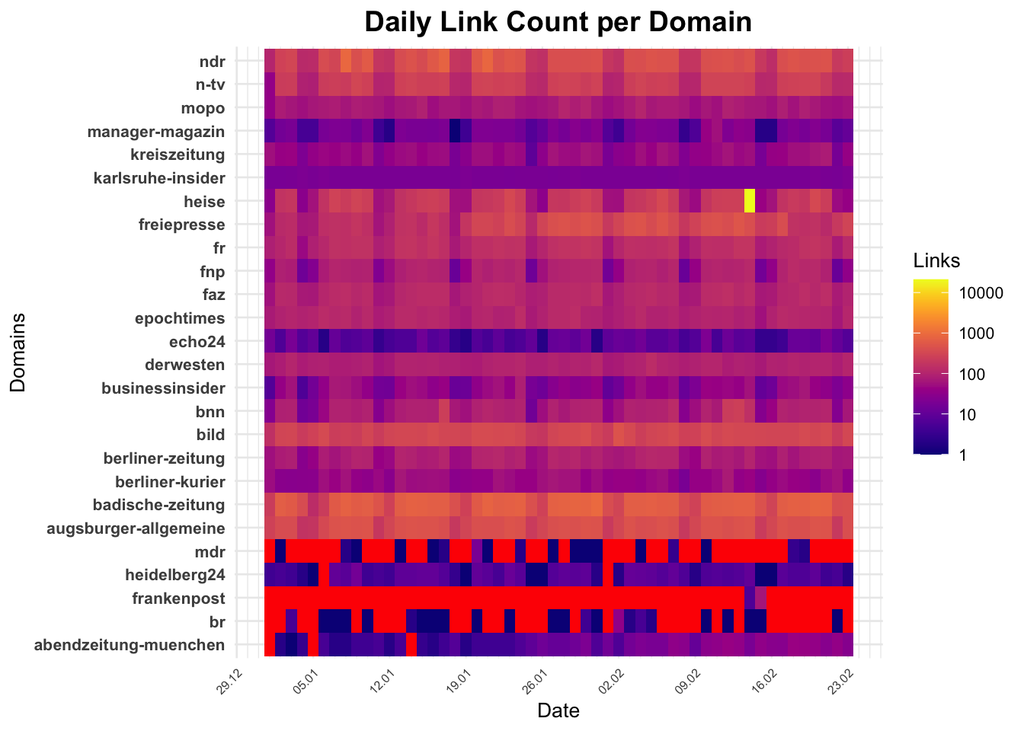

```r
# Prepare data for plotting
step_8_plot_data <- step_6_results_dt_filtered %>%
  mutate(date = coalesce(pub_date, lastmod_date)) %>%
  filter(!is.na(date)) %>%
  group_by(domain_url, date) %>%
  summarise(link_count = n(), .groups = "drop")

# Ensure step_8_plot_data is a data.table
step_8_plot_data <- as.data.table(step_8_plot_data)

# Clean domain names (remove TLDs)
step_8_plot_data[, domain_clean := str_remove(domain_url, "\\..*")]

# Create complete date-domain grid for all combinations
all_dates <- seq.Date(as.Date("2024-12-29"), as.Date("2025-02-23"), by = "day")
all_domains <- unique(step_8_plot_data$domain_clean)
complete_grid <- CJ(date = all_dates, domain_clean = all_domains)

# Merge with data and set 0 for missing combinations
step_8_plot_data_complete <- merge(
  complete_grid,
  step_8_plot_data[, .(date, domain_clean, link_count)],
  by = c("date", "domain_clean"),
  all.x = TRUE
)[, link_count := replace_na(link_count, 0L)]

# Add zero flag
step_8_plot_data_complete[, zero_flag := link_count == 0]

# Factor for alphabetical order
step_8_plot_data_complete[, domain_clean := factor(domain_clean, levels = sort(unique(domain_clean)))]

# Split domains into two equal groups
domain_levels <- levels(step_8_plot_data_complete$domain_clean)
n <- length(domain_levels)
half <- ceiling(n / 2)
domain_group1 <- domain_levels[1:half]
domain_group2 <- domain_levels[(half + 1):n]

# Helper function to create heatmap plot
plot_heatmap <- function(domain_subset, filename) {
  data_subset <- step_8_plot_data_complete[domain_clean %in% domain_subset]

  p <- ggplot() +
    geom_tile(data = data_subset[zero_flag == TRUE & date >= as.Date("2025-01-01")],
              aes(x = date, y = domain_clean), fill = "red") +
    geom_tile(data = data_subset[link_count > 0],
              aes(x = date, y = domain_clean, fill = link_count)) +
    scale_fill_viridis(option = "C", name = "Links", trans = "log10",
                       breaks = c(1, 10, 100, 1000, 10000)) +
    theme_minimal(base_size = 10) +
    theme(
      axis.text.x = element_text(angle = 45, hjust = 1, size = 6),
      axis.text.y = element_text(size = 8, face = "bold"),  # Made domain labels larger and bold
      plot.title = element_text(size = 14, face = "bold", hjust = 0.5),
      panel.background = element_rect(fill = "white", color = NA),
      plot.background = element_rect(fill = "white", color = NA)
    ) +
    labs(
      title = "Daily Link Count per Domain",
      x = "Date",
      y = "Domains"
    ) +
    scale_x_date(
      breaks = seq(as.Date("2024-12-29"), as.Date("2025-02-23"), by = "7 days"),
      date_minor_breaks = "1 day",
      date_labels = "%d.%m"
    )

  # Save the plot
  ggsave(filename = file.path(step_1_logging_folder, filename),
         plot = p, width = 16, height = 10, dpi = 300)

  # Return the plot object for HTML display
  return(p)
}

# Generate both heatmaps and display them
heatmap_part1 <- plot_heatmap(domain_group1, "plot_step_8_heatmap_all_domains_part1.png")
heatmap_part2 <- plot_heatmap(domain_group2, "plot_step_8_heatmap_all_domains_part2.png")

# Helper function to create faceted plot
plot_facet <- function(domain_subset, filename) {
  data_subset <- step_8_plot_data_complete[domain_clean %in% domain_subset]

  facet_plot <- ggplot(data_subset, aes(x = date, y = link_count)) +
    geom_line(color = "steelblue", size = 0.5) +
    geom_area(alpha = 0.3, fill = "steelblue") +
    facet_wrap(~domain_clean, scales = "free_y", ncol = 7) +
    theme_minimal(base_size = 10) +
    theme(
      axis.text.x = element_text(angle = 45, hjust = 1, size = 4),
      axis.text.y = element_text(size = 4),
      strip.text = element_text(size = 4),
      plot.title = element_text(size = 14, face = "bold", hjust = 0.5),
      axis.title.x = element_blank(),
      axis.title.y = element_blank(),
      panel.background = element_rect(fill = "white", color = NA),
      plot.background = element_rect(fill = "white", color = NA)
    ) +
    labs(title = "Daily Link Count Trends per Domain") +
    scale_x_date(
      limits = c(as.Date("2024-12-29"), as.Date("2025-02-23")),
      breaks = seq(as.Date("2024-12-29"), as.Date("2025-02-23"), by = "7 days"),
      date_minor_breaks = "1 day",
      date_labels = "%d.%m"
    )

  caption_text <- textGrob("X-axis: Date | Y-axis: Link Count", gp = gpar(fontsize = 10), hjust = 0.5)
  final_plot <- plot_grid(facet_plot, caption_text, ncol = 1, rel_heights = c(1, 0.04))

  # Save the plot
  ggsave(filename = file.path(step_1_logging_folder, filename),
         plot = final_plot, width = 20, height = 12, dpi = 300)

  # Return the plot object for HTML display
  return(final_plot)
}

# Generate both facet plots and display them
facet_part1 <- plot_facet(domain_group1, "plot_step_8_facet_all_domains_part1.png")
facet_part2 <- plot_facet(domain_group2, "plot_step_8_facet_all_domains_part2.png")

# Display heatmaps in HTML
print(heatmap_part1)
```

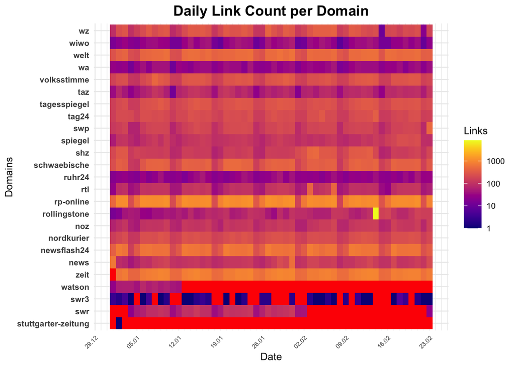

```r
print(heatmap_part2)
```

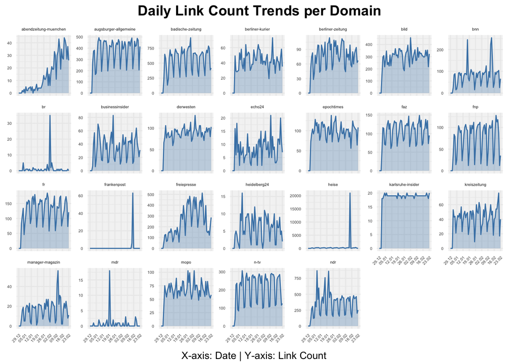

```r
# Display facet plots in HTML
print(facet_part1)
```

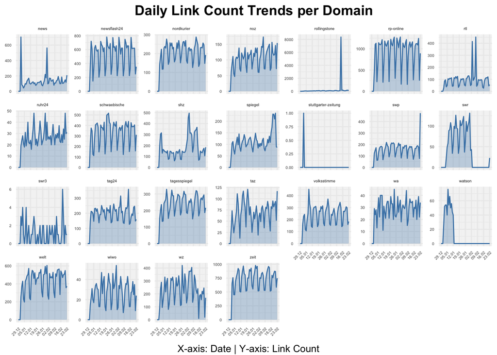

```r
print(facet_part2)
```

```r
cat("Step 8 completed: Heatmaps and Faceted Trends (2 parts each) plotted and saved.\n")
```

```
## Step 8 completed: Heatmaps and Faceted Trends (2 parts each) plotted and saved.
```

## Saving the Results:

### Summary:

This chunks saves the cleaned data set and the data set containing all links into the output folder.

```r
# Save the cleaned results table
saveRDS(
  step_6_results_dt_filtered,
  file = file.path(step_1_output_folder, "all_links_filtered_by_date.rds")
)

saveRDS(
  step_6_results_dt_all_links,
  file = file.path(step_1_output_folder, "all_links.rds")
)


cat("Step 9 completed: All data saved.\n")
```

```
## Step 9 completed: All data saved.
```